# #TidyTuesday Week 4

# Beeswarm plots

- Although not ideal to show distributions, I thought beeswarm plots would be good to show differences in the gender composition of job classes across different levels of taxable income
- A log scale is used to pull in extreme observations, as [suggested by @a40ruhr](https://twitter.com/a40ruhr/status/988880737238577153?s=20).
- Note that this is a distribution of gender-occupation combinations!

[figure not shown]

```r
# rounding for nicer beeswarms
tax2$income <- round(tax2$`Average taxable income\r\n$`, -4)

# copied function for scientific formatting of axes ticks
fancy_scientific <- function(l) {
     # turn in to character string in scientific notation
     l <- format(l, scientific = TRUE)
     # quote the part before the exponent to keep all the digits
     l <- gsub("^(.*)e", "'\\1'e", l)
     # turn the 'e+' into plotmath format
     l <- gsub("e", "%*%10^", l)
     # return this as an expression
     parse(text=l)
}

library(ggbeeswarm)
ggplot(tax2, aes(FactorTopcode, income, color = Gender)) +
  geom_beeswarm(cex = .11, shape = 15, size = 1) + coord_flip() +
  theme_minimal() +
  theme(plot.title = element_text(hjust = 0.5),
        plot.subtitle = element_text(hjust = 0.5),
        panel.grid.major.y = element_blank(),
        panel.grid.minor = element_blank(),
        plot.caption = element_text(hjust = 0.5, color = 'grey38'),
        legend.position = 'right') +
  scale_y_continuous(trans = 'log10', labels=fancy_scientific) +
  labs(title = "Distribution of occupations by average taxable income",
         subtitle = "Males occupy the top-paying jobs in most job categories",
         y = "Average annual taxable income ('000 AUD)", x = element_blank(),
       caption = "\nTaxation Statistics 2013-14, source: data.gov.au")
```

# Gender-occuption combinations don’t mean much …

- not unless they’re weighted by the number of people with that income.
- Weighted average of income by occupation class is calculated
- Also [weighted average income as percentage of male income](https://twitter.com/a40ruhr/status/988880995079274498?s=20)

```r
# calculating weighted income
tax2$`Average taxable income\r\n$`*tax2$`Individuals\r\nno.` -> tax2$weightinc

# calculating weighted average female income as proportion of weighted average male income

tax2 %>%
  group_by(FactorTopcode, Gender) %>%
  summarise(inc = sum(weightinc, na.rm = TRUE),
            weights = sum(`Individuals\r\nno.`, na.rm = TRUE)) -> tax3

tax3 %>% mutate(deweightinc = inc/weights) %>%
  select(-inc, -weights) %>% spread(Gender, deweightinc) %>%
  mutate(prop = Female/Male*100) -> tax3a

tax3a %>% merge(tax3, by = 'FactorTopcode') -> tax3a
tax3a[tax3a$Gender=='Male', 'prop'] = 100
```

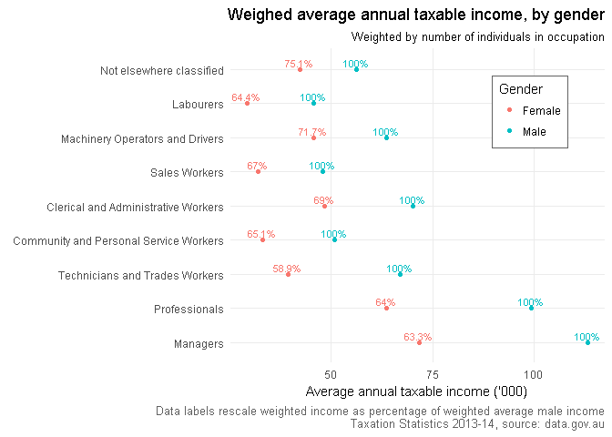

```r
tax3a %>%
  ggplot(aes(x = inc/weights/10e2, y = FactorTopcode, color = Gender)) +
  geom_point() +
  theme_minimal() + geom_text(aes(label = paste0(round(prop,1),'%')),
                              nudge_y = 0.2, show.legend= FALSE,
                              size = 3) +
  labs(x = "Average annual taxable income ('000)", y = element_blank(),
       title = "Weighed average annual taxable income, by gender",
       subtitle = "Weighted by number of individuals in occupation",
       caption = "Data labels rescale weighted income as percentage of weighted average male income\n Taxation Statistics 2013-14, source: data.gov.au") +
  theme(plot.title = element_text(hjust = 1),
        plot.subtitle = element_text(hjust = 1),
        legend.position = c(.8,.8),
        legend.background = element_rect(fill = 'white', color = 'grey38'),
        plot.caption = element_text(hjust = 1, color = 'grey38'),
        panel.grid.minor.x = element_blank())
```